# Classification Models

## Discussion questions

Suppose you are developing a classification model to determine whether or not a person has a particular disease (based on symptoms, results of diagnostic tests, family history, risk factors, etc).

1. Explain what “precision” represents in this context.

**Discuss with your partner, and make notes here.**

Precision is the people predicted to have the disease who actually have it.

2. Explain what “recall” represents in this context.

**Discuss with your partner, and make notes here.**

Recall is the people who have the disease that the model correctly identifies.

3. Which of the following do you think is a more serious error? It’s an opinion question, but choose one and discuss.
- Concluding that a person has the disease if they actually don’t have it
- Failing to conclude that a person has the disease if they actually do have it

**Discuss with your partner, and make notes here.** Failing to conclude somewho has the disease is more serious because they wouldn’t be treated right away.

4. Given your answer to the previous question, which would you prefer to be higher: precision or recall?

**Discuss with your partner, and make notes here.** I would prefer higher recall because it helps catch more people who actually have the disease

5. Suppose you want to achieve higher recall. Should your classification rule be more or less strict about who it predicts to have the disease?

**Discuss with your partner, and make notes here.** The rule should be less strict, so more people are predicted to have the disease.

6. What is a downside to your choice in the previous part?

**Discuss with your partner, and make notes here.** A downside is more false positives,

```python
import pandas as pd
import numpy as np
```

## More wine

The wines data set (https://dlsun.github.io/pods/data/wines.csv ) contains data about the chemical composition of various wines. We’ll first use just two features—fixed acidity and volatile acidity—to predict the color of the wine (red or white).

```python
df_train = pd.read_csv("https://dlsun.github.io/pods/data/wines.csv")

df_train
```

|  | fixed acidity | volatile acidity | citric acid | residual sugar | chlorides | free sulfur dioxide | total sulfur dioxide | density | pH | sulphates | alcohol | quality | color |
| --- | --- | --- | --- | --- | --- | --- | --- | --- | --- | --- | --- | --- | --- |
| 0 | 7.4 | 0.70 | 0.00 | 1.9 | 0.076 | 11.0 | 34.0 | 0.99780 | 3.51 | 0.56 | 9.4 | 5 | red |
| 1 | 7.8 | 0.88 | 0.00 | 2.6 | 0.098 | 25.0 | 67.0 | 0.99680 | 3.20 | 0.68 | 9.8 | 5 | red |
| 2 | 7.8 | 0.76 | 0.04 | 2.3 | 0.092 | 15.0 | 54.0 | 0.99700 | 3.26 | 0.65 | 9.8 | 5 | red |
| 3 | 11.2 | 0.28 | 0.56 | 1.9 | 0.075 | 17.0 | 60.0 | 0.99800 | 3.16 | 0.58 | 9.8 | 6 | red |
| 4 | 7.4 | 0.70 | 0.00 | 1.9 | 0.076 | 11.0 | 34.0 | 0.99780 | 3.51 | 0.56 | 9.4 | 5 | red |
| ... | ... | ... | ... | ... | ... | ... | ... | ... | ... | ... | ... | ... | ... |
| 6492 | 6.2 | 0.21 | 0.29 | 1.6 | 0.039 | 24.0 | 92.0 | 0.99114 | 3.27 | 0.50 | 11.2 | 6 | white |
| 6493 | 6.6 | 0.32 | 0.36 | 8.0 | 0.047 | 57.0 | 168.0 | 0.99490 | 3.15 | 0.46 | 9.6 | 5 | white |
| 6494 | 6.5 | 0.24 | 0.19 | 1.2 | 0.041 | 30.0 | 111.0 | 0.99254 | 2.99 | 0.46 | 9.4 | 6 | white |
| 6495 | 5.5 | 0.29 | 0.30 | 1.1 | 0.022 | 20.0 | 110.0 | 0.98869 | 3.34 | 0.38 | 12.8 | 7 | white |
| 6496 | 6.0 | 0.21 | 0.38 | 0.8 | 0.020 | 22.0 | 98.0 | 0.98941 | 3.26 | 0.32 | 11.8 | 6 | white |

6497 rows × 13 columns

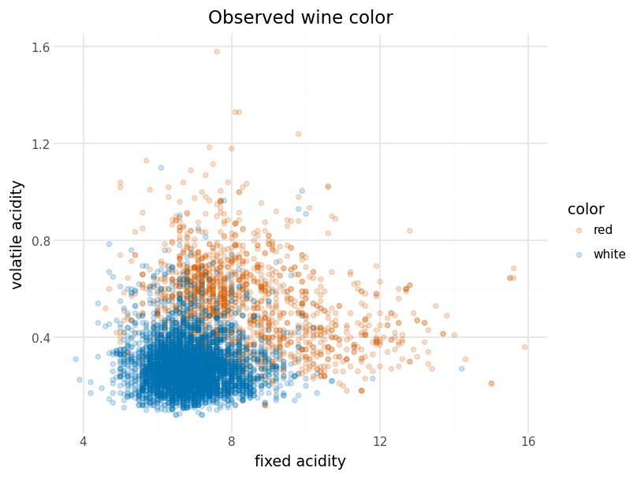

```python
from plotnine import *

(
    ggplot(df_train, aes(x="fixed acidity", y="volatile acidity", color="color"))
    + geom_point(alpha=0.2)
    + scale_color_manual(values={"red": "#D55E00", "white": "#0072B2"})
    + labs(title="Observed wine color")
    + theme_minimal()
)
```

1. Fit a 15-nearest neighbors model for predicting color from fixed acidity and volatile acidity. Don’t forget to scale the features. Create a scatter plot of the predicted wine colors for the training data, and compare visually to the observed colors.

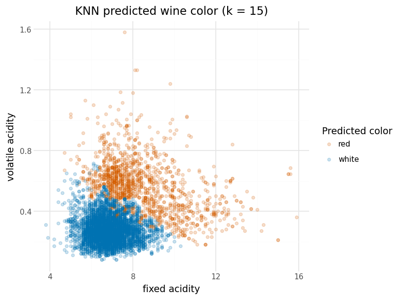

```python
# YOUR CODE HERE
from sklearn.model_selection import cross_validate, GridSearchCV
from sklearn.neighbors import KNeighborsClassifier
from sklearn.pipeline import make_pipeline
from sklearn.preprocessing import StandardScaler

features = ["fixed acidity", "volatile acidity"]
X_two_features = df_train[features]
y = df_train["color"]

knn_15 = make_pipeline(
    StandardScaler(),
    KNeighborsClassifier(n_neighbors=15)
)

knn_15.fit(X_two_features, y)
df_train["knn_prediction"] = knn_15.predict(X_two_features)

(
    ggplot(df_train, aes(x="fixed acidity", y="volatile acidity", color="knn_prediction"))
    + geom_point(alpha=0.2)
    + scale_color_manual(values={"red": "#D55E00", "white": "#0072B2"})
    + labs(title="KNN predicted wine color (k = 15)", color="Predicted color")
    + theme_minimal()
)
```

2. Use 10-fold cross-validation to estimate the test precision, recall, and F1 score using `macro` scoring.

```python
# YOUR CODE HERE
knn_scores = cross_validate(
    knn_15,
    X_two_features,
    y,
    cv=10,
    scoring=["precision_macro", "recall_macro", "f1_macro"]
)

pd.Series({
    "Precision (macro)": knn_scores["test_precision_macro"].mean(),
    "Recall (macro)": knn_scores["test_recall_macro"].mean(),
    "F1 score (macro)": knn_scores["test_f1_macro"].mean()
}).round(3)
```

```
Precision (macro)    0.882
Recall (macro)       0.855
F1 score (macro)     0.864
dtype: float64
```

3. Use `GridSearchCV` to fit $k$-nearest neighbors models for $k=1,\ldots, 30$ and use cross validation to estimate the test F1 macro score. Plot the test score versus $k$. Which value of $k$ yields the best score?

```python
# YOUR CODE HERE
knn_grid = make_pipeline(
    StandardScaler(),
    KNeighborsClassifier()
)

search = GridSearchCV(
    knn_grid,
    {"kneighborsclassifier__n_neighbors": range(1, 31)},
    cv=10,
    scoring="f1_macro"
)

search.fit(X_two_features, y)

knn_results = pd.DataFrame({
    "k": range(1, 31),
    "F1 macro score": search.cv_results_["mean_test_score"]
})

(
    ggplot(knn_results, aes(x="k", y="F1 macro score"))
    + geom_line()
    + geom_point()
    + labs(title="10-fold CV F1 macro score by k")
    + theme_minimal()
)

print("Best k:", search.best_params_["kneighborsclassifier__n_neighbors"])
print("Best F1 macro score:", round(search.best_score_, 3))
```

[output not shown]

```
Best k: 16
Best F1 macro score: 0.867
```

4. When the target variable is binary **logistic regression** provides another classification algorithm.

Fit a logistic regression model for predicting wine color from the two features. Create a scatter plot of the predicted wine colors for the training data, and compare visually to the predictions from the nearest neighbors classifier.

Note: with regression, you don’t need to scale the features (unless you add a penalty). Hint: you basically just need to replace with `KNeighborsClassifier()` with `LogisticRegression()`.

```python
from sklearn.linear_model import LogisticRegression
```

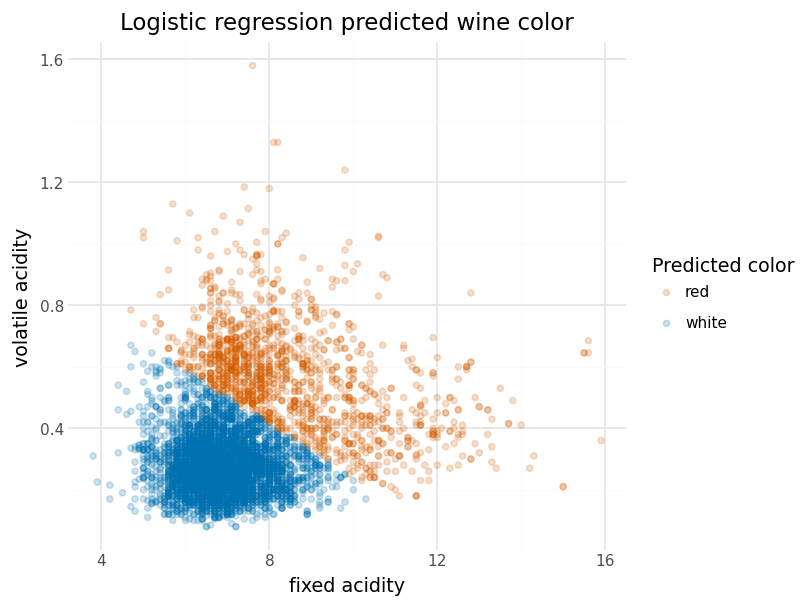

```python
# YOUR CODE HERE
logistic_two_features = LogisticRegression(
    penalty=None,
    max_iter=1000
)

logistic_two_features.fit(X_two_features, y)
df_train["logistic_prediction"] = logistic_two_features.predict(X_two_features)

(
    ggplot(df_train, aes(x="fixed acidity", y="volatile acidity", color="logistic_prediction"))
    + geom_point(alpha=0.2)
    + scale_color_manual(values={"red": "#D55E00", "white": "#0072B2"})
    + labs(title="Logistic regression predicted wine color", color="Predicted color")
    + theme_minimal()
)
```

5. Use 10-fold cross-validation to estimate the test precision, recall, and F1 score of the logistic regression model using `macro` scoring. Compare to the nearest neighbors model.

```python
# YOUR CODE HERE
logistic_scores = cross_validate(
    logistic_two_features,
    X_two_features,
    y,
    cv=10,
    scoring=["precision_macro", "recall_macro", "f1_macro"]
)

pd.DataFrame({
    "KNN (k = 15)": [
        knn_scores["test_precision_macro"].mean(),
        knn_scores["test_recall_macro"].mean(),
        knn_scores["test_f1_macro"].mean()
    ],
    "Logistic regression": [
        logistic_scores["test_precision_macro"].mean(),
        logistic_scores["test_recall_macro"].mean(),
        logistic_scores["test_f1_macro"].mean()
    ]
}, index=["Precision (macro)", "Recall (macro)", "F1 score (macro)"]).round(3)
```

|  | KNN (k = 15) | Logistic regression |
| --- | --- | --- |
| Precision (macro) | 0.882 | 0.892 |
| Recall (macro) | 0.855 | 0.852 |
| F1 score (macro) | 0.864 | 0.865 |

6. Now fit a logistic regression model using all of the potential predictors. Use 10-fold cross-validation to estimate the test precision, recall, and F1 score of the logistic regression model using `macro` scoring.

```python
# YOUR CODE HERE
all_features = df_train.drop(columns=["color", "knn_prediction", "logistic_prediction"])

logistic_all_features = LogisticRegression(
    penalty=None,
    max_iter=1000
)

all_feature_scores = cross_validate(
    logistic_all_features,
    all_features,
    y,
    cv=10,
    scoring=["precision_macro", "recall_macro", "f1_macro"]
)

pd.Series({
    "Precision (macro)": all_feature_scores["test_precision_macro"].mean(),
    "Recall (macro)": all_feature_scores["test_recall_macro"].mean(),
    "F1 score (macro)": all_feature_scores["test_f1_macro"].mean()
}).round(3)
```

[output not shown]

[output cut: 11 more lines]

[output not shown]

```
Precision (macro)    0.986
Recall (macro)       0.982
F1 score (macro)     0.984
dtype: float64
```

7. Now fit a logistic regression model using all of the potential predictors with a LASSO (`"l1"`) penalty. Use 10-fold cross-validation to estimate the test precision, recall, and F1 score of the logistic regression model using `macro` scoring.

```python
# YOUR CODE HERE
lasso_logistic = make_pipeline(
    StandardScaler(),
    LogisticRegression(
        penalty="l1",
        solver="liblinear",
        max_iter=1000
    )
)

lasso_scores = cross_validate(
    lasso_logistic,
    all_features,
    y,
    cv=10,
    scoring=["precision_macro", "recall_macro", "f1_macro"]
)

pd.Series({
    "Precision (macro)": lasso_scores["test_precision_macro"].mean(),
    "Recall (macro)": lasso_scores["test_recall_macro"].mean(),
    "F1 score (macro)": lasso_scores["test_f1_macro"].mean()
}).round(3)
```

```
Precision (macro)    0.992
Recall (macro)       0.990
F1 score (macro)     0.991
dtype: float64
```